# Udemy Course Analysis

Kushagra Sen

1/13/2020

### About the Dataset:

**- The dataset is about the musical instrument courses that are been taken up on Udemy.com**

**- The data is taken from:** https://data.world/chasewillden/musical-instrument-courses-from-udemy.

- The dataset is in a **CSV format** and includes the following entities:
1. id - The course ID
2. title - The course Title
3. url - The course URL
4. isPaid - Tells Whether the course is paid or not
5. price - The price of course in USD
6. numSubscribers - Number of subscribers for a course
7. numReviews - Number of reviews given for that course
8. numPublishedLectures - Number of lectures published
9. instructionalLevel - The level of course (Beginner, Intermediate and All Levels)
10. contentInfo - Duration of course
11. publishedTime - Date and Time stamp

### **Step 1:** Reading the data as shown below.

```r
df<-read.csv("https://drive.google.com/uc?export=download&id=1MqDHRuT278II3x5qib-DXc6ePQaciRwr")
datatable(df)
```

|  | id | title | url | isPaid | price | numSubscribers | numReviews | numPublishedLectures | instructionalLevel | contentInfo | publishedTime | Column1 | X | Is.Paid | Total | Percent |
| --- | --- | --- | --- | --- | --- | --- | --- | --- | --- | --- | --- | --- | --- | --- | --- | --- |
| 1 | 696630 | 7 Ways A Beginner Guitarist Can Sound Better, Instantly! | https://www.udemy.com/nationalguitaracademy/ | FALSE | Free | 4529 | 193 | 7 | Beginner Level | 36 mins | 2015-12-21T18:50:50Z |  |  | Yes | 634 | 93% |
| 2 | 643970 | Instant Harmonica - Christmas. Play Jingle Bells Part 1 now | https://www.udemy.com/instant-harmonica-christmas-play-jingle-bells-part-1-now/ | TRUE | 20 | 823 | 11 | 10 | All Levels | 42 mins | 2015-12-11T18:42:43Z |  |  | No | 46 | 7% |
| 3 | 801486 | Playing Piano: Popular Pieces Vol. II | https://www.udemy.com/playing-piano-popular-pieces-volii/ | TRUE | 150 | 1472 | 4 | 24 | Beginner Level | 1.5 hours | 2016-03-31T17:24:49Z |  |  |  |  |  |
| 4 | 455054 | Ninja Chord Changes - Master your guitar chord changes | https://www.udemy.com/ninja-chord-changes/ | TRUE | 30 | 1327 | 11 | 13 | Beginner Level | 1.5 hours | 2015-03-29T21:57:12Z |  |  |  |  |  |
| 5 | 1257976 | Your First 10 Guitar Lessons - Learn how to play guitar | https://www.udemy.com/your-first-10-guitar-lessons-learn-how-to-play-guitar/ | FALSE | Free | 924 | 4 | 18 | Beginner Level | 1 hour | 2017-06-29T00:29:36Z |  |  |  |  |  |
| 6 | 1253224 | Pentatonic Scale Crash Course for Bass Guitar | https://www.udemy.com/pentatonic-scale-crash-course-for-bass-guitar/ | FALSE | Free | 898 | 6 | 24 | Intermediate Level | 1 hour | 2017-06-15T18:35:07Z |  |  |  |  |  |
| 7 | 837722 | Modal Theory for Guitar (Guitar Lessons from Lutz Academy) | https://www.udemy.com/modal-theory-for-guitar/ | TRUE | 50 | 1039 | 29 | 9 | All Levels | 1.5 hours | 2016-05-06T15:32:00Z |  |  |  |  |  |
| 8 | 631416 | Learn Fun Dreamy Piano Techniques #1 - Play White Christmas | https://www.udemy.com/learn-piano-christmas-song-play-dreamy-piano-music-white-christmas/ | TRUE | 80 | 1474 | 10 | 102 | All Levels | 2 hours | 2015-10-20T22:41:19Z |  |  |  |  |  |
| 9 | 149728 | Learn Jazz Piano Today | https://www.udemy.com/learn-jazz-piano-with-willie-today/ | TRUE | 50 | 1167 | 66 | 44 | All Levels | 3 hours | 2014-01-24T18:17:37Z |  |  |  |  |  |
| 10 | 195576 | Learn To Play The Drums Without A Drum Kit | https://www.udemy.com/learn-to-play-the-drums-without-a-drum-kit/ | TRUE | 25 | 1589 | 52 | 39 | All Levels | 2 hours | 2014-06-27T21:54:58Z |  |  |  |  |  |

[output cut: 671 more lines]

### Cleaning the data:

For this analysis, we dont need some specific columns, so they are being dropped:

```r
df1 <- (select (df,-c(title,url,Column1,X,Is.Paid,Total,Percent)))
datatable(df1)
```

|  | id | isPaid | price | numSubscribers | numReviews | numPublishedLectures | instructionalLevel | contentInfo | publishedTime |
| --- | --- | --- | --- | --- | --- | --- | --- | --- | --- |
| 1 | 696630 | FALSE | Free | 4529 | 193 | 7 | Beginner Level | 36 mins | 2015-12-21T18:50:50Z |
| 2 | 643970 | TRUE | 20 | 823 | 11 | 10 | All Levels | 42 mins | 2015-12-11T18:42:43Z |
| 3 | 801486 | TRUE | 150 | 1472 | 4 | 24 | Beginner Level | 1.5 hours | 2016-03-31T17:24:49Z |
| 4 | 455054 | TRUE | 30 | 1327 | 11 | 13 | Beginner Level | 1.5 hours | 2015-03-29T21:57:12Z |
| 5 | 1257976 | FALSE | Free | 924 | 4 | 18 | Beginner Level | 1 hour | 2017-06-29T00:29:36Z |
| 6 | 1253224 | FALSE | Free | 898 | 6 | 24 | Intermediate Level | 1 hour | 2017-06-15T18:35:07Z |
| 7 | 837722 | TRUE | 50 | 1039 | 29 | 9 | All Levels | 1.5 hours | 2016-05-06T15:32:00Z |
| 8 | 631416 | TRUE | 80 | 1474 | 10 | 102 | All Levels | 2 hours | 2015-10-20T22:41:19Z |
| 9 | 149728 | TRUE | 50 | 1167 | 66 | 44 | All Levels | 3 hours | 2014-01-24T18:17:37Z |
| 10 | 195576 | TRUE | 25 | 1589 | 52 | 39 | All Levels | 2 hours | 2014-06-27T21:54:58Z |

[output cut: 671 more lines]

### **Step 2:** This step includes tidying up the data.

The column **publishedTime** is in the format *YYYY-MM-DD-Hours-Minutes-Seconds* and might cause an issue to group the yearly, monthly or hourly time while performing the analysis.There is also a character appended at the end of publishedTime which is unnecessary and should be removed.

```r
df2<- df1 %>%
  separate(publishedTime
           , into = c("Date", "Time"), sep = "T")
df3 <- df2 %>%
  separate(Date
           , into = c("Year", "Month", "Day"), sep = "-")
#Again some cleaning
df3 = filter(df3, Year != "3 hours")
df3$Time = str_replace(df3$Time,"Z","")

datatable(df3)
```

|  | id | isPaid | price | numSubscribers | numReviews | numPublishedLectures | instructionalLevel | contentInfo | Year | Month | Day | Time |
| --- | --- | --- | --- | --- | --- | --- | --- | --- | --- | --- | --- | --- |
| 1 | 696630 | FALSE | Free | 4529 | 193 | 7 | Beginner Level | 36 mins | 2015 | 12 | 21 | 18:50:50 |
| 2 | 643970 | TRUE | 20 | 823 | 11 | 10 | All Levels | 42 mins | 2015 | 12 | 11 | 18:42:43 |
| 3 | 801486 | TRUE | 150 | 1472 | 4 | 24 | Beginner Level | 1.5 hours | 2016 | 03 | 31 | 17:24:49 |
| 4 | 455054 | TRUE | 30 | 1327 | 11 | 13 | Beginner Level | 1.5 hours | 2015 | 03 | 29 | 21:57:12 |
| 5 | 1257976 | FALSE | Free | 924 | 4 | 18 | Beginner Level | 1 hour | 2017 | 06 | 29 | 00:29:36 |
| 6 | 1253224 | FALSE | Free | 898 | 6 | 24 | Intermediate Level | 1 hour | 2017 | 06 | 15 | 18:35:07 |
| 7 | 837722 | TRUE | 50 | 1039 | 29 | 9 | All Levels | 1.5 hours | 2016 | 05 | 06 | 15:32:00 |
| 8 | 631416 | TRUE | 80 | 1474 | 10 | 102 | All Levels | 2 hours | 2015 | 10 | 20 | 22:41:19 |
| 9 | 149728 | TRUE | 50 | 1167 | 66 | 44 | All Levels | 3 hours | 2014 | 01 | 24 | 18:17:37 |
| 10 | 195576 | TRUE | 25 | 1589 | 52 | 39 | All Levels | 2 hours | 2014 | 06 | 27 | 21:54:58 |

[output cut: 670 more lines]

### **Step 3:** Graphical Representation

*Earlier, with the untidy data, It was not feasible to visualize the Yearly or Monthly trends.*

**Graph 1** **The graph below shows the yearly trend for the Number of subscribers. We can see a significant dip in the number of subscribers from 2016 to 2017. If it was an untidy data, this trend wouln’t have been noticed**

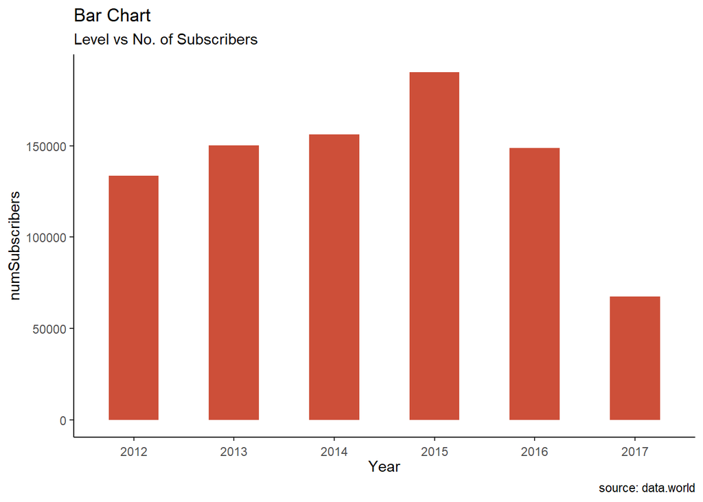

```r
theme_set(theme_classic())

ggplot(df3, aes(x=Year, y=numSubscribers)) +
  geom_bar(stat="identity", width=.5, fill="tomato3") +
  labs(title="Bar Chart",
       subtitle="Level vs No. of Subscribers",
       caption="source: data.world") +
  theme(axis.text.x = element_text(angle=0, vjust=0.2))
```

**Graph 2** **This pie chart below shows the number of lectures published every month. Clearly, April (04) and May (05) have the most number of lectures published, while the least is in the month of September (09)**

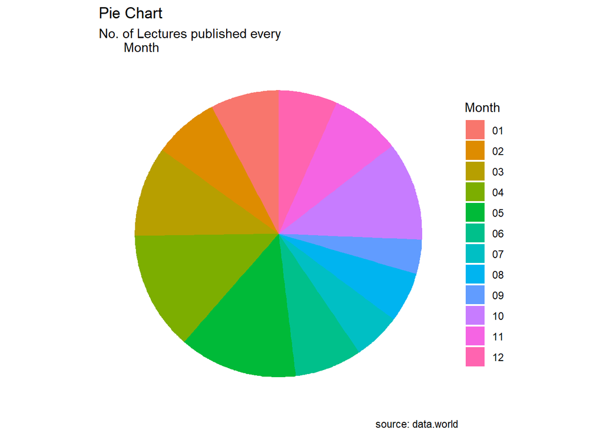

```r
ggplot(df3, aes(x="", y=numPublishedLectures, fill = Month)) +
  geom_bar(stat = "identity", width = 4) + coord_polar("y", start=0) +
  labs(title="Pie Chart",
       subtitle="No. of Lectures published every
       Month",
       caption="source: data.world") +
  theme_void()
```

### As we have seen the importance to tidying up the data, we can say that Udemy needs to spread their database schema to save the “publishedTime” in seperate columns. This will help the analysts to understand the Yearly, Monthly and Daily trends with respect to other important entities in the dataset.